# Assignment 3

by Zina Kamel, Hiba Akbi, Alyn Nazal

(December 5, 2023)

# Problem Selection

In light of the time context of this assignment, the approaching end of the semester and finals period is the moment university and educational institutions send their students course evaluation forms to assess their feedback and experience from the courses they have taken within the semester.

While our analysis and results are adequate to Queensland university and its students, to a certain extent, the results of this work can be extended to the other institutions to tailor the educational experience of their students to their needs, and refine the strategies of course delivery for an enhanced student performance and quality of teaching at the university.

# Dataset Selection

The dataset we have provided is a tabular representation of survey or assessment data. It comprises various columns, each offering insights into different aspects of the survey. These include mean scores (MeanQ1 to MeanQ8) for different questions, providing an overview of overall responses. The column “AgreeQ8” was present but has been removed. The source of the dataset did not provide details of what the AgreeQ8 column represents and it seems that it has been generated for the purposes of their research, so we will not be considering it in our analysis.

Other key columns include:

```
TotalResponses: Reflects the total number of responses received for the survey or assessment.
Class_size: Indicates the size of the class or group participating in the survey.
ResponseRate: Represents the percentage of responses received out of the total potential responses.
Year and Semester: Provide information about when the survey was conducted.
Campus: Specifies the location or campus where the survey took place.
DeliveryMode: Distinguishes between internal and external survey delivery.
No_Academics: Appears to be associated with the number of academic staff or faculty
Prelude: A categorical variable, possibly related to the introductory section of the survey.
Rank and Gender: Include details about the rank and gender of the survey participants.
```

This dataset appears to cover multiple years, with responses from various campuses, delivery modes, and participant demographics

# Getting Started

We start our work by importing the relevant libraries.

```r
library(conflicted)
library(dplyr)
library(purrr)
library(tidyverse)
```

```r
library(magrittr)
library(ggplot2)
library(MASS)
library(ROCR)
library(caret)
library(e1071)
library(ggcorrplot)
library(randomForest)
library(xgboost)
library(gbm)
library(factoextra)
conflict_prefer("filter", "dplyr")
```

```
## [conflicted] Will prefer dplyr::filter over any other package.
```

```r
conflict_prefer("lag", "dplyr")
```

```
## [conflicted] Will prefer dplyr::lag over any other package.
```

Then we import our data set through the `read.scv()` command. Note that the data set file must be available in the current working file directory.

```r
# Set strings as factors to load them as categorical data
data <- read.csv("dataset.csv", stringsAsFactors = TRUE)
```

```r
head(data)
```

```
##   MeanQ1 MeanQ2 MeanQ3 MeanQ4 MeanQ5 MeanQ6 MeanQ7 MeanQ8 AgreeQ8
## 1   4.46   4.38   4.32   4.13   4.16   4.19   4.34   4.36     90%
## 2   4.06   4.16   3.90   4.06   4.09   3.65   4.26   4.07     80%
## 3   4.33   4.44   4.11   4.33   4.44   3.78   4.44   4.44     89%
## 4   4.03   3.65   3.85   4.03   4.04   3.63   4.08   3.73     59%
## 5   3.89   3.67   3.44   3.56   4.00   3.33   3.78   3.67     56%
## 6   3.37   3.10   3.18   3.11   3.68   2.83   2.98   2.97     30%
##   TotalResponses Class_size ResponseRate Year Semester   Campus DeliveryMode
## 1             68         85          80% 2018        1   Gatton     Internal
## 2             69        353          20% 2018        1   Gatton     Internal
## 3              9         47          19% 2018        1 External     External
## 4             74        365          20% 2018        1   Gatton     Internal
## 5              9         41          22% 2018        1 External     External
## 6             90        317          28% 2018        1   Gatton     Internal
##   No_Academics Prelude  Rank Gender
## 1            1    AGRC OTHER      M
## 2            5    AGRC OTHER      F
## 3            5    AGRC OTHER      F
## 4            9    AGRC OTHER      F
## 5            9    AGRC OTHER      F
## 6            2    AGRC OTHER      M
```

As explained earlier, we will drop the feature ‘AgreeQ8’, we do this through the index of the column.

```r
data <- data[, -9]
str(data)
```

```
## 'data.frame':    485 obs. of  19 variables:
##  $ MeanQ1        : num  4.46 4.06 4.33 4.03 3.89 3.37 3.67 3.73 3.93 3.33 ...
##  $ MeanQ2        : num  4.38 4.16 4.44 3.65 3.67 3.1 3.56 3.67 4.27 3.22 ...
##  $ MeanQ3        : num  4.32 3.9 4.11 3.85 3.44 3.18 3.22 3.78 4.13 3 ...
##  $ MeanQ4        : num  4.13 4.06 4.33 4.03 3.56 3.11 3.33 3.95 3.6 3.33 ...
##  $ MeanQ5        : num  4.16 4.09 4.44 4.04 4 3.68 3.89 3.5 3.73 3.44 ...
##  $ MeanQ6        : num  4.19 3.65 3.78 3.63 3.33 2.83 2.67 3.49 3.13 2.5 ...
##  $ MeanQ7        : num  4.34 4.26 4.44 4.08 3.78 2.98 3.11 3.8 3.87 3.44 ...
##  $ MeanQ8        : num  4.36 4.07 4.44 3.73 3.67 2.97 3.13 3.67 3.87 2.89 ...
##  $ TotalResponses: int  68 69 9 74 9 90 9 45 15 9 ...
##  $ Class_size    : int  85 353 47 365 41 317 36 79 21 29 ...
##  $ ResponseRate  : Factor w/ 77 levels "100%","14%","15%",..: 65 7 6 7 9 15 12 43 57 18 ...
##  $ Year          : int  2018 2018 2018 2018 2018 2018 2018 2018 2018 2018 ...
##  $ Semester      : int  1 1 1 1 1 1 1 1 1 1 ...
##  $ Campus        : Factor w/ 3 levels "External","Gatton",..: 2 2 1 2 1 2 1 2 3 1 ...
##  $ DeliveryMode  : Factor w/ 5 levels "External","FlexibleDelivery",..: 4 4 1 4 1 4 1 4 4 1 ...
##  $ No_Academics  : Factor w/ 15 levels "1","10","11",..: 1 9 9 13 13 6 6 2 2 2 ...
##  $ Prelude       : Factor w/ 17 levels "AGRC","ANIM",..: 1 1 1 1 1 1 1 1 1 1 ...
##  $ Rank          : Factor w/ 3 levels "ASSOCIATE_PROFESSOR",..: 2 2 2 2 2 2 2 3 3 3 ...
##  $ Gender        : Factor w/ 2 levels "F","M": 2 1 1 1 1 2 2 1 1 1 ...
```

**Renaming columns**

Before proceeding to the exploratory analysis, we want to facilitate the reading by giving more descriptive names to our columns. Let’s rename them:

```r
names(data)
```

```
##  [1] "MeanQ1"         "MeanQ2"         "MeanQ3"         "MeanQ4"
##  [5] "MeanQ5"         "MeanQ6"         "MeanQ7"         "MeanQ8"
##  [9] "TotalResponses" "Class_size"     "ResponseRate"   "Year"
## [13] "Semester"       "Campus"         "DeliveryMode"   "No_Academics"
## [17] "Prelude"        "Rank"           "Gender"
```

```r
names(data)[names(data) == 'MeanQ1'] <- 'clearUnderstanding'
names(data)[names(data) == 'MeanQ2'] <- 'intellectuallySimulating'
names(data)[names(data) == 'MeanQ4'] <- 'materialsUsefulness'
names(data)[names(data) == 'MeanQ5'] <- 'clearRequirements'
names(data)[names(data) == 'MeanQ3'] <- 'goodStructure'
names(data)[names(data) == 'MeanQ6'] <- 'feedbackReceived'
names(data)[names(data) == 'MeanQ7'] <- 'learningOutcome'
names(data)[names(data) == 'MeanQ8'] <- 'overallRating'
names(data)[names(data) == 'Class_size'] <- 'classSize'
names(data)[names(data) == 'No_Academics'] <- 'noAcademics'
names(data)
```

```
##  [1] "clearUnderstanding"       "intellectuallySimulating"
##  [3] "goodStructure"            "materialsUsefulness"
##  [5] "clearRequirements"        "feedbackReceived"
##  [7] "learningOutcome"          "overallRating"
##  [9] "TotalResponses"           "classSize"
## [11] "ResponseRate"             "Year"
## [13] "Semester"                 "Campus"
## [15] "DeliveryMode"             "noAcademics"
## [17] "Prelude"                  "Rank"
## [19] "Gender"
```

Our data now look as follows:

```r
head(data)
```

```
##   clearUnderstanding intellectuallySimulating goodStructure materialsUsefulness
## 1               4.46                     4.38          4.32                4.13
## 2               4.06                     4.16          3.90                4.06
## 3               4.33                     4.44          4.11                4.33
## 4               4.03                     3.65          3.85                4.03
## 5               3.89                     3.67          3.44                3.56
## 6               3.37                     3.10          3.18                3.11
##   clearRequirements feedbackReceived learningOutcome overallRating
## 1              4.16             4.19            4.34          4.36
## 2              4.09             3.65            4.26          4.07
## 3              4.44             3.78            4.44          4.44
## 4              4.04             3.63            4.08          3.73
## 5              4.00             3.33            3.78          3.67
## 6              3.68             2.83            2.98          2.97
##   TotalResponses classSize ResponseRate Year Semester   Campus DeliveryMode
## 1             68        85          80% 2018        1   Gatton     Internal
## 2             69       353          20% 2018        1   Gatton     Internal
## 3              9        47          19% 2018        1 External     External
## 4             74       365          20% 2018        1   Gatton     Internal
## 5              9        41          22% 2018        1 External     External
## 6             90       317          28% 2018        1   Gatton     Internal
##   noAcademics Prelude  Rank Gender
## 1           1    AGRC OTHER      M
## 2           5    AGRC OTHER      F
## 3           5    AGRC OTHER      F
## 4           9    AGRC OTHER      F
## 5           9    AGRC OTHER      F
## 6           2    AGRC OTHER      M
```

**Numerical and Categorical Data**

The table tells us that we have a mix of both, numerical values (represented as num and int) and categorical ones (represented as Factor).

We notice that the % values in ‘Response Rate’ are set as Factors, so we map them to become num.

```r
data$ResponseRate <- as.numeric(gsub("%", "", as.character(data$ResponseRate)))
str(data)
```

```
## 'data.frame':    485 obs. of  19 variables:
##  $ clearUnderstanding      : num  4.46 4.06 4.33 4.03 3.89 3.37 3.67 3.73 3.93 3.33 ...
##  $ intellectuallySimulating: num  4.38 4.16 4.44 3.65 3.67 3.1 3.56 3.67 4.27 3.22 ...
##  $ goodStructure           : num  4.32 3.9 4.11 3.85 3.44 3.18 3.22 3.78 4.13 3 ...
##  $ materialsUsefulness     : num  4.13 4.06 4.33 4.03 3.56 3.11 3.33 3.95 3.6 3.33 ...
##  $ clearRequirements       : num  4.16 4.09 4.44 4.04 4 3.68 3.89 3.5 3.73 3.44 ...
##  $ feedbackReceived        : num  4.19 3.65 3.78 3.63 3.33 2.83 2.67 3.49 3.13 2.5 ...
##  $ learningOutcome         : num  4.34 4.26 4.44 4.08 3.78 2.98 3.11 3.8 3.87 3.44 ...
##  $ overallRating           : num  4.36 4.07 4.44 3.73 3.67 2.97 3.13 3.67 3.87 2.89 ...
##  $ TotalResponses          : int  68 69 9 74 9 90 9 45 15 9 ...
##  $ classSize               : int  85 353 47 365 41 317 36 79 21 29 ...
##  $ ResponseRate            : num  80 20 19 20 22 28 25 57 71 31 ...
##  $ Year                    : int  2018 2018 2018 2018 2018 2018 2018 2018 2018 2018 ...
##  $ Semester                : int  1 1 1 1 1 1 1 1 1 1 ...
##  $ Campus                  : Factor w/ 3 levels "External","Gatton",..: 2 2 1 2 1 2 1 2 3 1 ...
##  $ DeliveryMode            : Factor w/ 5 levels "External","FlexibleDelivery",..: 4 4 1 4 1 4 1 4 4 1 ...
##  $ noAcademics             : Factor w/ 15 levels "1","10","11",..: 1 9 9 13 13 6 6 2 2 2 ...
##  $ Prelude                 : Factor w/ 17 levels "AGRC","ANIM",..: 1 1 1 1 1 1 1 1 1 1 ...
##  $ Rank                    : Factor w/ 3 levels "ASSOCIATE_PROFESSOR",..: 2 2 2 2 2 2 2 3 3 3 ...
##  $ Gender                  : Factor w/ 2 levels "F","M": 2 1 1 1 1 2 2 1 1 1 ...
```

Before starting with the data exploration, let us have a look at the statistics of the different variables. For this, we will use the `summary()` command.

```r
summary(data)
```

```
##  clearUnderstanding intellectuallySimulating goodStructure
##  Min.   :2.000      Min.   :2.130            Min.   :1.750
##  1st Qu.:3.870      1st Qu.:3.820            1st Qu.:3.670
##  Median :4.280      Median :4.210            Median :4.110
##  Mean   :4.149      Mean   :4.131            Mean   :3.993
##  3rd Qu.:4.540      3rd Qu.:4.530            3rd Qu.:4.430
##  Max.   :5.000      Max.   :5.000            Max.   :5.000
##
##  materialsUsefulness clearRequirements feedbackReceived learningOutcome
##  Min.   :2.250       Min.   :1.73      Min.   :1.300    Min.   :1.930
##  1st Qu.:3.780       1st Qu.:3.68      1st Qu.:3.440    1st Qu.:3.830
##  Median :4.140       Median :4.15      Median :3.960    Median :4.240
##  Mean   :4.048       Mean   :4.01      Mean   :3.866    Mean   :4.142
##  3rd Qu.:4.420       3rd Qu.:4.46      3rd Qu.:4.330    3rd Qu.:4.560
##  Max.   :5.000       Max.   :5.00      Max.   :5.000    Max.   :5.000
##
##  overallRating   TotalResponses    classSize       ResponseRate
##  Min.   :1.600   Min.   : 5.00   Min.   :  7.00   Min.   : 14.00
##  1st Qu.:3.640   1st Qu.: 9.00   1st Qu.: 19.00   1st Qu.: 33.00
##  Median :4.110   Median :14.00   Median : 30.00   Median : 46.00
##  Mean   :4.006   Mean   :18.13   Mean   : 46.02   Mean   : 49.39
##  3rd Qu.:4.500   3rd Qu.:21.00   3rd Qu.: 47.00   3rd Qu.: 64.00
##  Max.   :5.000   Max.   :95.00   Max.   :365.00   Max.   :100.00
##
##       Year         Semester          Campus              DeliveryMode
##  Min.   :2015   Min.   :1.000   External: 82   External        : 78
##  1st Qu.:2016   1st Qu.:1.000   Gatton  :259   FlexibleDelivery: 10
##  Median :2016   Median :1.000   StLucia :144   Intensive       :  3
##  Mean   :2016   Mean   :1.487                  Internal        :388
##  3rd Qu.:2017   3rd Qu.:2.000                  WebBased        :  6
##  Max.   :2018   Max.   :2.000
##
##   noAcademics     Prelude                     Rank     Gender
##  1      :173   AGRC   :146   ASSOCIATE_PROFESSOR:118   F:180
##  2      :118   ANIM   :106   OTHER              :234   M:305
##  3      : 65   FOOD   : 58   PROFESSOR          :133
##  4      : 47   LAND   : 26
##  5      : 33   ENVM   : 23
##  6      : 20   BIOL   : 21
##  (Other): 29   (Other):105
```

Moving on, we now need to check for any unusual categorical values in our columns, before plotting charts. We will do this by printing the unique values in categorical column. (Unsual vlaues in numerical columns are outliers and we will handle them later on in the document)

```r
categorical_cols <- data %>%
  select_if(is.factor) %>%
  names()

cat("Unique values for categorical columns:\n")
```

```
## Unique values for categorical columns:
```

```r
walk(categorical_cols, ~{
  cat("Column", .x, ":\n")
  print(unique(data[[.x]]))
  cat("\n")
})
```

```
## Column Campus :
## [1] Gatton   External StLucia
## Levels: External Gatton StLucia
##
## Column DeliveryMode :
## [1] Internal         External         FlexibleDelivery WebBased
## [5] Intensive
## Levels: External FlexibleDelivery Intensive Internal WebBased
##
## Column noAcademics :
##  [1] 1            5            9            2            10
##  [6] 6            4            3            8            7
## [11] 16           missing_data missing      11           13
## Levels: 1 10 11 13 16 2 3 4 5 6 7 8 9 missing missing_data
##
## Column Prelude :
##  [1] AGRC ANIM BIOL CHEM ENVM FINM FOOD LAND LPWM MGTS MICR MKTG PLNT HORT IBUS
## [16] STAT BOTN
## 17 Levels: AGRC ANIM BIOL BOTN CHEM ENVM FINM FOOD HORT IBUS LAND LPWM ... STAT
##
## Column Rank :
## [1] OTHER               PROFESSOR           ASSOCIATE_PROFESSOR
## Levels: ASSOCIATE_PROFESSOR OTHER PROFESSOR
##
## Column Gender :
## [1] M F
## Levels: F M
```

The data shows that the noAcademics contains “missing” and “missing data” string values so we filter them out. Once that is done, we can map the variable to be numerical.

```r
unique(data$noAcademics)
```

```
##  [1] 1            5            9            2            10
##  [6] 6            4            3            8            7
## [11] 16           missing_data missing      11           13
## Levels: 1 10 11 13 16 2 3 4 5 6 7 8 9 missing missing_data
```

```r
data <- data[!(grepl("missing", data$noAcademics) | grepl("missing_data", data$noAcademics)), ]
data$noAcademics <- as.numeric(as.character(data$noAcademics))
unique(data$noAcademics)
```

```
##  [1]  1  5  9  2 10  6  4  3  8  7 16 11 13
```

# Data Exploration

We can now proceed with a descriptive exploratory analysis. We start by plotting the distribution of the different features we have

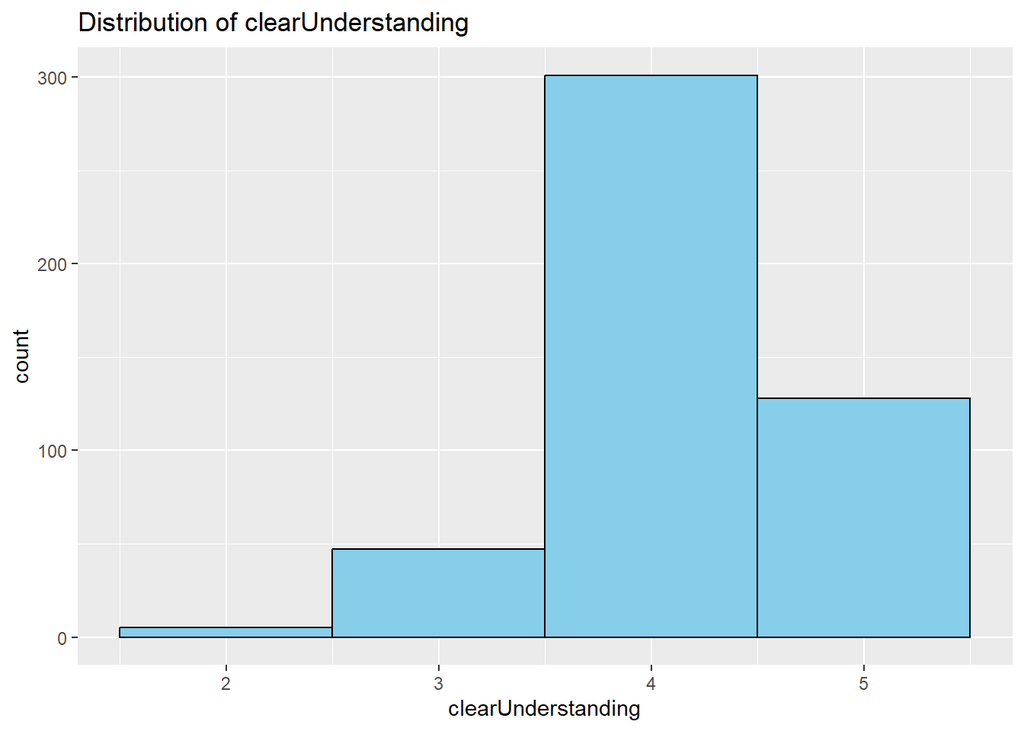

```r
ggplot(data, aes(x = clearUnderstanding)) +
  geom_histogram(binwidth = 1, fill = "skyblue", color = "black") +
  labs(title = "Distribution of clearUnderstanding")
```

We have chosen to plot a histogram for the clearUnderstanding column since it is a continous numerical variable. From the histogram, we can visualize the distribution of this feature. We could notice that the highest frequency was for a clearUnderstanding score between 3.5 and 4.5.

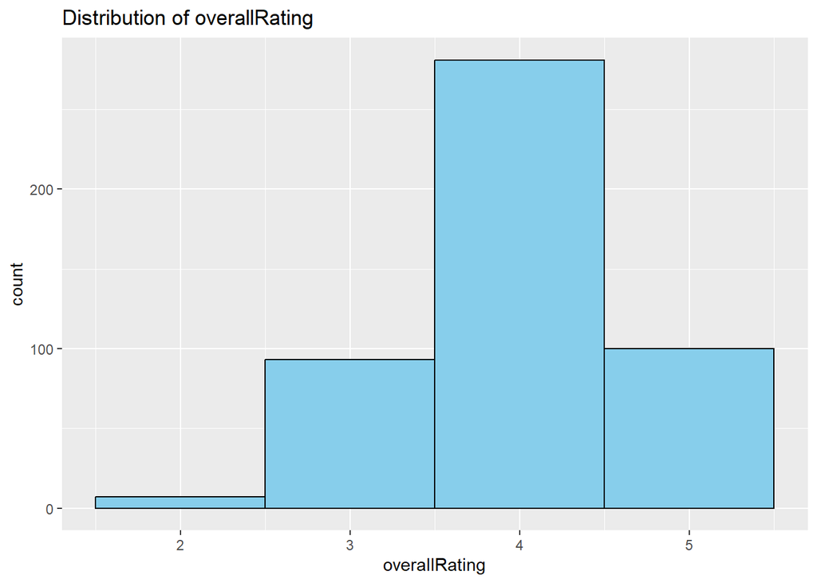

```r
ggplot(data, aes(x = overallRating)) +
  geom_histogram(binwidth = 1, fill = "skyblue", color = "black") +
  labs(title = "Distribution of overallRating")
```

Similarly, most of the courses had rating between 3.5 and 4.5

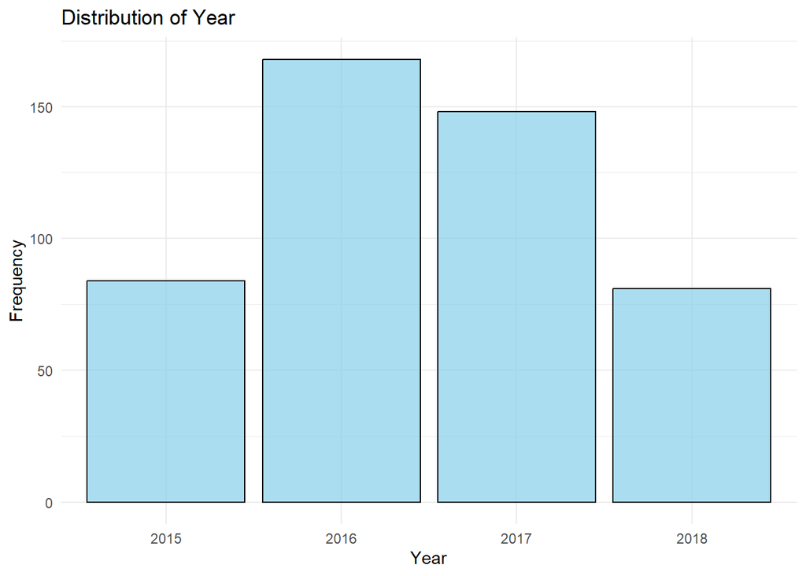

```r
ggplot(data, aes(x = as.factor(Year))) +
  geom_bar(fill = "skyblue", color = "black", alpha = 0.7) +
  labs(title = "Distribution of Year", x = "Year", y = "Frequency") +
  theme_minimal()
```

When plotting the distribution of the years, we notice a more balanced distribution across the 4 different years in the dataset

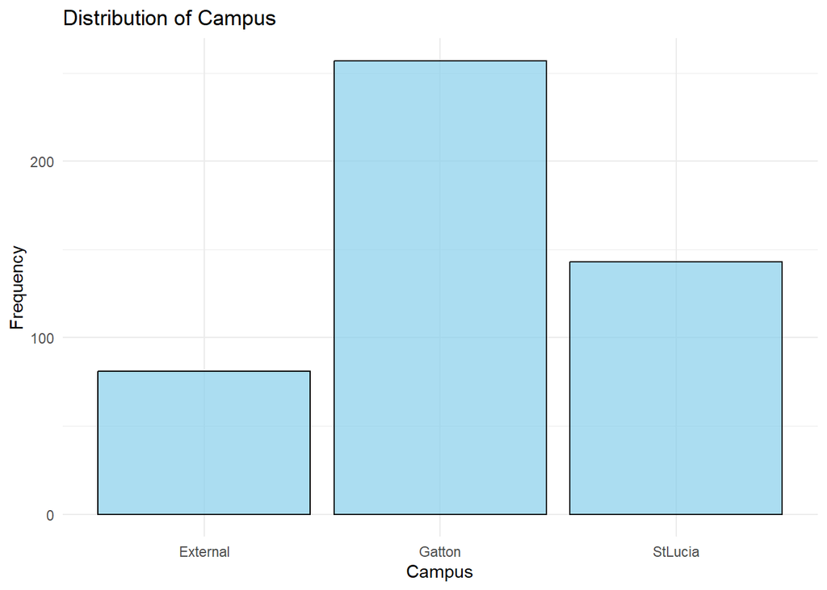

```r
ggplot(data, aes(x = as.factor(Campus))) +
  geom_bar(fill = "skyblue", color = "black", alpha = 0.7) +
  labs(title = "Distribution of Campus", x = "Campus", y = "Frequency") +
  theme_minimal()
```

The majority of the courses were delivered in the Gatton campus followed by StLucia then External campuses

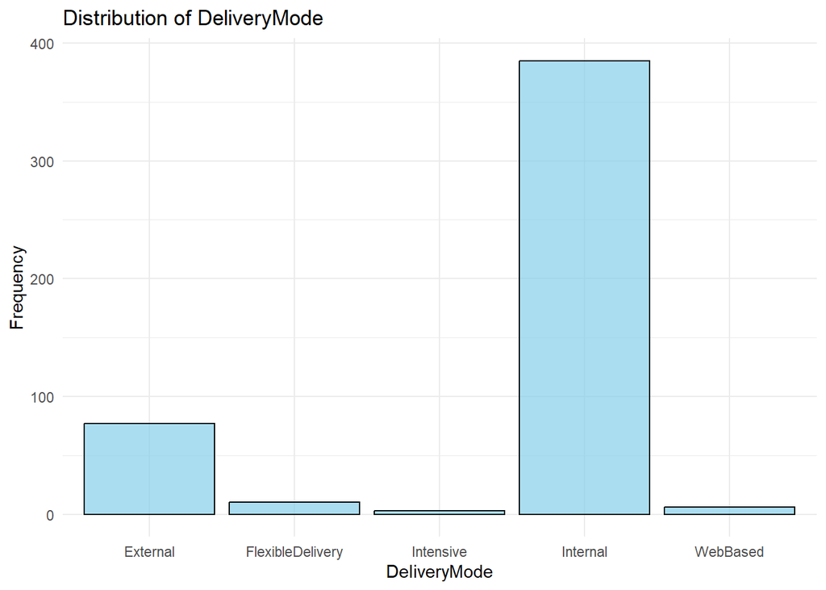

```r
ggplot(data, aes(x = as.factor(DeliveryMode))) +
  geom_bar(fill = "skyblue", color = "black", alpha = 0.7) +
  labs(title = "Distribution of DeliveryMode", x = "DeliveryMode", y = "Frequency") +
  theme_minimal()
```

When visualising the distribution of the Delivery Modes, we notice that a large majority of the courses had Internal delivery mode.

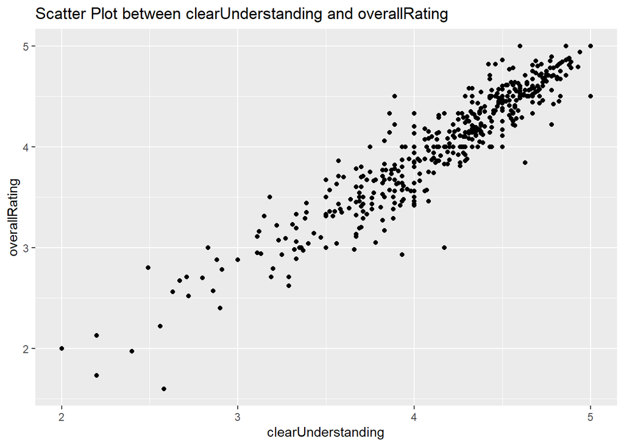

```r
ggplot(data, aes(x = clearUnderstanding, y = overallRating)) +
  geom_point() +
  labs(title = "Scatter Plot between clearUnderstanding and overallRating")
```

Through the scatter plot, we can notice that we have a positive correlation between the clearUnderstanding and overallRating. Hence, the clearer the understanding of students the higher the rating.

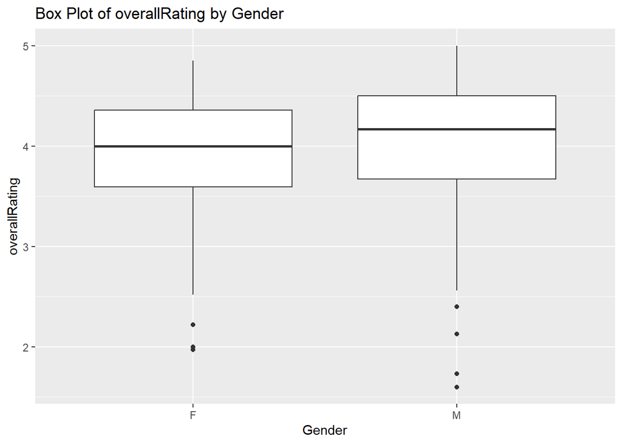

```r
ggplot(data, aes(x = Gender, y = overallRating)) +
  geom_boxplot() +
  labs(title = "Box Plot of overallRating by Gender")
```

Using a boxplot graph, we notice that the overallRating mean among males and females was close to each other, with males having slightly higher ratings.

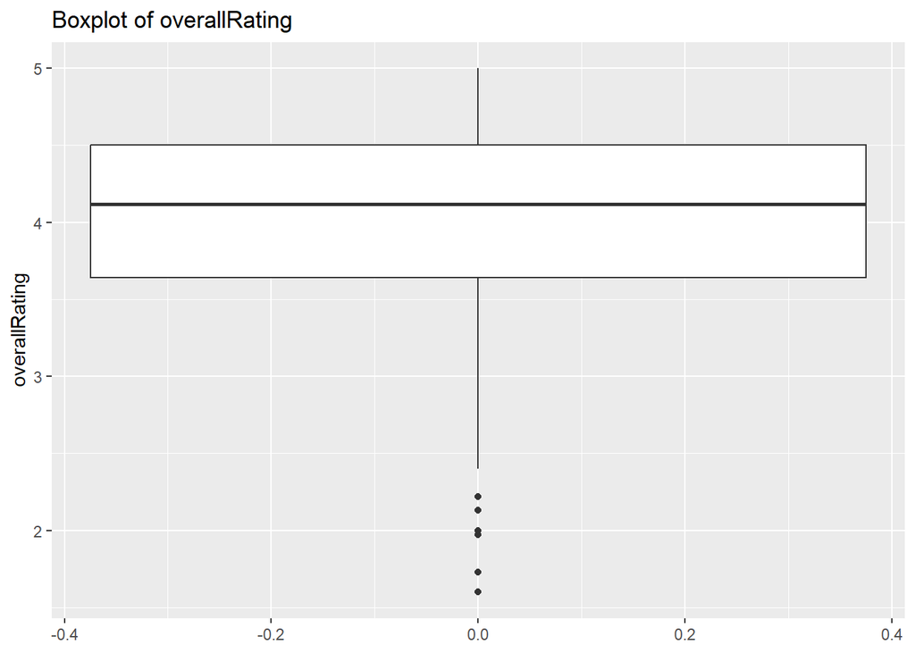

```r
ggplot(data, aes(y = overallRating)) +
  geom_boxplot() +
  labs(title = "Boxplot of overallRating")
```

When graphing one of the numerical columns (overallRating), we notice the presence of outliers. We will tackle the outliers in this column as well as other numerical columns in the Preprocessing Data section.

**Exploring the colinearity of features**

In order to select our most significant features, we want to explore the collinearity between our predictors. We generate a correlation matrix and plot it as a heat map as follows:

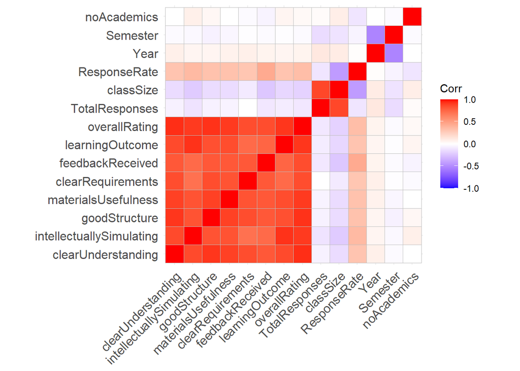

```r
numeric_columns <- data %>% select_if(is.numeric)
corr_matrix <- cor(numeric_columns)
ggcorrplot(corr_matrix)
```

Next, we explore the association between our response variable `overall score` and the categorical features.

```r
model <- lm(overallRating ~ Campus + Rank + Gender + Prelude + DeliveryMode, data = data)
anova_result <- anova(model)
print(anova_result)
```

```
## Analysis of Variance Table
##
## Response: overallRating
##               Df  Sum Sq Mean Sq F value    Pr(>F)
## Campus         2   5.925 2.96234 10.4172 3.771e-05 ***
## Rank           2   4.425 2.21228  7.7795 0.0004763 ***
## Gender         1   0.799 0.79855  2.8081 0.0944753 .
## Prelude       16  27.593 1.72456  6.0645 3.392e-12 ***
## DeliveryMode   4   1.042 0.26044  0.9158 0.4544500
## Residuals    455 129.389 0.28437
## ---
## Signif. codes:  0 '***' 0.001 '**' 0.01 '*' 0.05 '.' 0.1 ' ' 1
```

The results suggests the following:

- Campus, Rank and Prelude were all significant features to the overall course rating.
- On the other hand, the gender of the academic and the delivery mode of the course had little significance to the course rating.

We will be dropping these two features when fitting our upcoming models.

# Preprocessing Data

Preprocessing our data is a crucial step to our work, as it readies the data to be suitable and reliable for the machine learning models.

We start the preprocessing by taking a look at the structure of our data set and variables. We do this using the `str()` command.

```r
str(data)
```

```
## 'data.frame':    481 obs. of  19 variables:
##  $ clearUnderstanding      : num  4.46 4.06 4.33 4.03 3.89 3.37 3.67 3.73 3.93 3.33 ...
##  $ intellectuallySimulating: num  4.38 4.16 4.44 3.65 3.67 3.1 3.56 3.67 4.27 3.22 ...
##  $ goodStructure           : num  4.32 3.9 4.11 3.85 3.44 3.18 3.22 3.78 4.13 3 ...
##  $ materialsUsefulness     : num  4.13 4.06 4.33 4.03 3.56 3.11 3.33 3.95 3.6 3.33 ...
##  $ clearRequirements       : num  4.16 4.09 4.44 4.04 4 3.68 3.89 3.5 3.73 3.44 ...
##  $ feedbackReceived        : num  4.19 3.65 3.78 3.63 3.33 2.83 2.67 3.49 3.13 2.5 ...
##  $ learningOutcome         : num  4.34 4.26 4.44 4.08 3.78 2.98 3.11 3.8 3.87 3.44 ...
##  $ overallRating           : num  4.36 4.07 4.44 3.73 3.67 2.97 3.13 3.67 3.87 2.89 ...
##  $ TotalResponses          : int  68 69 9 74 9 90 9 45 15 9 ...
##  $ classSize               : int  85 353 47 365 41 317 36 79 21 29 ...
##  $ ResponseRate            : num  80 20 19 20 22 28 25 57 71 31 ...
##  $ Year                    : int  2018 2018 2018 2018 2018 2018 2018 2018 2018 2018 ...
##  $ Semester                : int  1 1 1 1 1 1 1 1 1 1 ...
##  $ Campus                  : Factor w/ 3 levels "External","Gatton",..: 2 2 1 2 1 2 1 2 3 1 ...
##  $ DeliveryMode            : Factor w/ 5 levels "External","FlexibleDelivery",..: 4 4 1 4 1 4 1 4 4 1 ...
##  $ noAcademics             : num  1 5 5 9 9 2 2 10 10 10 ...
##  $ Prelude                 : Factor w/ 17 levels "AGRC","ANIM",..: 1 1 1 1 1 1 1 1 1 1 ...
##  $ Rank                    : Factor w/ 3 levels "ASSOCIATE_PROFESSOR",..: 2 2 2 2 2 2 2 3 3 3 ...
##  $ Gender                  : Factor w/ 2 levels "F","M": 2 1 1 1 1 2 2 1 1 1 ...
```

**Missing Values**

Next, we handle any missing values in our data. Missing values can cause issues during model training and evaluation and imputing or removing them helps ensure the dataset is complete.

```r
# Remove rows with any missing values
which(is.na(data))
```

```
## integer(0)
```

There was no missing values in the dataset, thus we can move on.

Now that our data is clean of missing values, and interpreted correctly as categorical and numerical, we can proceed with the remaining steps of feature engineering.

# Feature Engineering

**Low Variance Features**

Features with low variance are features that have little differences if at all in their values across the different observations in the data set. Because these features hold little discriminatory power, we can omit them to reduce our dimensional without losing crucial information. We chose our definition of low variance here to be the default values used by the caret library ‘nearZeroVar’ function.

```r
low_variance_features <- nearZeroVar(data)

low_variance_features
```

```
## integer(0)
```

None of the features has a variance near zero, thus we keep all the features for now.

**Grouping features**

```r
unique(data$Prelude)
```

```
##  [1] AGRC ANIM BIOL CHEM ENVM FINM FOOD LAND LPWM MGTS MICR MKTG PLNT HORT IBUS
## [16] STAT BOTN
## 17 Levels: AGRC ANIM BIOL BOTN CHEM ENVM FINM FOOD HORT IBUS LAND LPWM ... STAT
```

We group our courses into fields as follows:

- Agricultural Sciences: AGRC, HORT, PLNT, FOOD
- Animal Sciences: ANIM
- Biological Sciences: BIOL, BOTN, MICR
- Environmental Sciences: ENVM, LAND, LPWM
- Business Management: FINM, IBUS, MGTS, MKTG
- Chemistry and Mathematics: CHEM, STAT

```r
course_to_field <- list(
  Agricultural_Sciences = c("AGRC", "HORT", "PLNT", "FOOD"),
  Animal_Sciences = c("ANIM"),
  Biological_Sciences = c("BIOL", "BOTN", "MICR"),
  Environmental_Sciences = c("ENVM", "LAND", "LPWM"),
  Business_Management = c("FINM", "IBUS", "MGTS", "MKTG"),
  Chemistry_Mathematics= c("CHEM", "STAT")
)

# Function to assign field based on course
get_field <- function(course) {
  for (field in names(course_to_field)) {
    if (course %in% unlist(course_to_field[field])) {
      return(field)
    }
  }
  return("Other")  # Default category if course doesn't match any rule
}

data$Field <- sapply(data$Prelude, get_field)
data$Field<-as.factor(data$Field)

summary(data$Field)
```

```
##  Agricultural_Sciences        Animal_Sciences    Biological_Sciences
##                    229                    105                     34
##    Business_Management  Chemistry_Mathematics Environmental_Sciences
##                     42                     19                     52
```

We can now drop the original Prelude column from the dataset

```r
data <- subset(data, select = -c(Prelude))
```

**Scaling**

Scaling ensures that all features have a similar influence on the model, and normalization can be important for certain algorithms that are sensitive to the scale of the input data.

```r
numeric_columns <- sapply(data,is.numeric)
data[, numeric_columns] <- scale(data[, numeric_columns])
```

```r
summary(data)
```

```
##  clearUnderstanding intellectuallySimulating goodStructure
##  Min.   :-4.1639    Min.   :-3.8281          Min.   :-3.7338
##  1st Qu.:-0.5306    1st Qu.:-0.5977          1st Qu.:-0.5285
##  Median : 0.2424    Median : 0.1478          Median : 0.1857
##  Mean   : 0.0000    Mean   : 0.0000          Mean   : 0.0000
##  3rd Qu.: 0.7449    3rd Qu.: 0.7595          3rd Qu.: 0.7338
##  Max.   : 1.6339    Max.   : 1.6579          Max.   : 1.6638
##  materialsUsefulness clearRequirements feedbackReceived  learningOutcome
##  Min.   :-3.4809     Min.   :-3.8285   Min.   :-4.0760   Min.   :-4.2118
##  1st Qu.:-0.5262     1st Qu.:-0.5476   1st Qu.:-0.6827   1st Qu.:-0.5991
##  Median : 0.1690     Median : 0.2224   Median : 0.1418   Median : 0.1805
##  Mean   : 0.0000     Mean   : 0.0000   Mean   : 0.0000   Mean   : 0.0000
##  3rd Qu.: 0.7290     3rd Qu.: 0.7580   3rd Qu.: 0.7285   3rd Qu.: 0.8080
##  Max.   : 1.8298     Max.   : 1.6452   Max.   : 1.7908   Max.   : 1.6256
##  overallRating     TotalResponses      classSize         ResponseRate
##  Min.   :-4.0607   Min.   :-0.9183   Min.   :-0.73053   Min.   :-1.7633
##  1st Qu.:-0.6245   1st Qu.:-0.6383   1st Qu.:-0.50514   1st Qu.:-0.8204
##  Median : 0.1841   Median :-0.2884   Median :-0.29853   Median :-0.1256
##  Mean   : 0.0000   Mean   : 0.0000   Mean   : 0.00000   Mean   : 0.0000
##  3rd Qu.: 0.8242   3rd Qu.: 0.2015   3rd Qu.: 0.02077   3rd Qu.: 0.7678
##  Max.   : 1.6664   Max.   : 5.3807   Max.   : 5.99366   Max.   : 2.5048
##       Year            Semester            Campus              DeliveryMode
##  Min.   :-1.5184   Min.   :-0.9764   External: 81   External        : 77
##  1st Qu.:-0.4854   1st Qu.:-0.9764   Gatton  :257   FlexibleDelivery: 10
##  Median :-0.4854   Median :-0.9764   StLucia :143   Intensive       :  3
##  Mean   : 0.0000   Mean   : 0.0000                  Internal        :385
##  3rd Qu.: 0.5476   3rd Qu.: 1.0221                  WebBased        :  6
##  Max.   : 1.5807   Max.   : 1.0221
##   noAcademics                       Rank     Gender
##  Min.   :-0.8137   ASSOCIATE_PROFESSOR:118   F:176
##  1st Qu.:-0.8137   OTHER              :233   M:305
##  Median :-0.3347   PROFESSOR          :130
##  Mean   : 0.0000
##  3rd Qu.: 0.6235
##  Max.   : 6.3725
##                     Field
##  Agricultural_Sciences :229
##  Animal_Sciences       :105
##  Biological_Sciences   : 34
##  Business_Management   : 42
##  Chemistry_Mathematics : 19
##  Environmental_Sciences: 52
```

**One hot encoding**

Our categorical variables include nominal data (campus, gender, delivery mode, prelude). Since there is no order, we go for one hot encoding.

```r
# campus
dummy <- dummyVars(" ~ Campus", data = data)
encoded_campus <- data.frame(predict(dummy, newdata = data))

# rank
dummy <- dummyVars(" ~ Rank", data = data)
encoded_rank <- data.frame(predict(dummy, newdata = data))

# prelude
dummy <- dummyVars(" ~ Field", data = data)
encoded_prelude <- data.frame(predict(dummy, newdata = data))

data <- cbind(data, encoded_campus, encoded_prelude, encoded_rank)
```

We can now drop the columns we just encoded as we won’t need them for the model training. We will also be dropping the Gender and DeliveryMode columns we identified as insignificant earlier.

```r
columns_to_drop <- c("Gender", "Campus", "DeliveryMode", "Rank", "Field")
data <- data[, !(names(data) %in% columns_to_drop)]
```

**Outliers**

Outliers can negatively impact the performance of some machine learning algorithms. Removing or adjusting them can improve model robustness. In the previous data exploration we did, we noticed the presence of outliers in our numerical columns, so we are now going to remove them.

```r
# Function to remove outliers based on IQR
remove_outliers <- function(x) {
  qnt <- quantile(x, c(0.05, 0.95), na.rm = TRUE)
  H <- 1.5 * IQR(x, na.rm = TRUE)
  x[(x < (qnt[1] - H)) | (x > (qnt[2] + H))] <- NA
  return(x)
}

# Apply the remove_outliers function to each numeric column
data[, numeric_columns] <- apply(data[, numeric_columns], 2, remove_outliers)

# Remove rows with any NA values (rows containing outliers)
data <- na.omit(data)
```

Our preprocessed and cleaned data looks as follows:

```r
glimpse(data)
```

```
## Rows: 443
## Columns: 26
## $ clearUnderstanding           <dbl> 0.33903036, -0.51131790, -0.93649203, -0.…
## $ intellectuallySimulating     <dbl> 0.5874812, -0.8843812, -1.0946473, -0.884…
## $ goodStructure                <dbl> 0.185692069, -0.927044695, -1.292420946, …
## $ materialsUsefulness          <dbl> 0.5359131, -0.9510972, -1.3952691, -0.197…
## $ clearRequirements            <dbl> 0.70781269, -0.02871063, -0.21284146, -0.…
## $ feedbackReceived             <dbl> -0.14363027, -0.85716649, -1.90368628, -0…
## $ learningOutcome              <dbl> 0.56078063, -0.69415677, -1.96810837, -0.…
## $ overallRating                <dbl> 0.7230861, -0.5739373, -1.4835382, -0.573…
## $ TotalResponses               <dbl> -0.63834359, -0.63834359, -0.63834359, 1.…
## $ classSize                    <dbl> 0.02077417, -0.09192178, -0.18583507, 0.6…
## $ ResponseRate                 <dbl> -1.5151864, -1.3662988, -1.2174113, 0.370…
## $ Year                         <dbl> 1.580656, 1.580656, 1.580656, 1.580656, 1…
## $ Semester                     <dbl> -0.9763701, -0.9763701, -0.9763701, -0.97…
## $ noAcademics                  <dbl> 1.1025953, 3.0189398, -0.3346631, 3.49802…
## $ Campus.External              <dbl> 1, 1, 1, 0, 0, 1, 1, 0, 1, 0, 0, 0, 0, 0,…
## $ Campus.Gatton                <dbl> 0, 0, 0, 1, 0, 0, 0, 1, 0, 1, 0, 1, 1, 1,…
## $ Campus.StLucia               <dbl> 0, 0, 0, 0, 1, 0, 0, 0, 0, 0, 1, 0, 0, 0,…
## $ Field.Agricultural_Sciences  <dbl> 1, 1, 1, 1, 1, 1, 1, 1, 1, 1, 1, 1, 1, 1,…
## $ Field.Animal_Sciences        <dbl> 0, 0, 0, 0, 0, 0, 0, 0, 0, 0, 0, 0, 0, 0,…
## $ Field.Biological_Sciences    <dbl> 0, 0, 0, 0, 0, 0, 0, 0, 0, 0, 0, 0, 0, 0,…
## $ Field.Business_Management    <dbl> 0, 0, 0, 0, 0, 0, 0, 0, 0, 0, 0, 0, 0, 0,…
## $ Field.Chemistry_Mathematics  <dbl> 0, 0, 0, 0, 0, 0, 0, 0, 0, 0, 0, 0, 0, 0,…
## $ Field.Environmental_Sciences <dbl> 0, 0, 0, 0, 0, 0, 0, 0, 0, 0, 0, 0, 0, 0,…
## $ Rank.ASSOCIATE_PROFESSOR     <dbl> 0, 0, 0, 0, 0, 0, 0, 0, 1, 0, 0, 0, 0, 1,…
## $ Rank.OTHER                   <dbl> 1, 1, 1, 0, 0, 0, 1, 1, 0, 0, 0, 0, 0, 0,…
## $ Rank.PROFESSOR               <dbl> 0, 0, 0, 1, 1, 1, 0, 0, 0, 1, 1, 1, 1, 0,…
```

# Model Development

Splitting the dataset into training and testing sets allows for model evaluation on unseen data. Before splitting, we shuffle the data incase any of the columns was ordered.

```r
set.seed(123)

# Shuffle the data
shuffled_index <- sample(nrow(data))
shuffled_data <- data[shuffled_index, ]

# Split into training and testing
split_index <- createDataPartition(shuffled_data$overallRating, p = 0.8, list = FALSE)
train_data <- shuffled_data[split_index, ]
test_data <- shuffled_data[-split_index, ]
```

Due to the one hot encoding and standardization, some columns ended up having a constant value across all rows. These do not contribute to the training of the model so we will remove them.

```r
constant_vars <- sapply(train_data, function(x) length(unique(x)) == 1)
constant_vars_names_train <- names(constant_vars[constant_vars])
print(constant_vars_names_train)
```

```
## [1] "Field.Chemistry_Mathematics"
```

```r
constant_vars <- sapply(test_data, function(x) length(unique(x)) == 1)
constant_vars_names_test <- names(constant_vars[constant_vars])
print(constant_vars_names_test)
```

```
## [1] "Field.Chemistry_Mathematics"
```

```r
train_data <- train_data[, !constant_vars]
```

```r
test_data <- test_data[, !constant_vars]
```

## Tree-Based Methods

In this section, we leverage the caret package in R to develop and assess machine learning models for predicting the “overallRating” variable, with a specific emphasis on the role of decision trees in our approach. The ensemble comprises a foundational decision tree, a pruned decision tree achieved through parameter tuning, a random forest model, and a gradient boosting model utilizing a Gaussian distribution. Through a 5-fold cross-validation strategy, we systematically train and evaluate each model. Notably, decision trees play a pivotal role in our methodology, serving as the building blocks for the ensemble and providing interpretability to the overall predictive framework. Post-resampling analysis calculates the Mean Squared Error for individual models on an independent test dataset, enabling a focused evaluation of how decision trees contribute to the predictive accuracy of the ensemble within the context of our broader project.

```r
suppressWarnings({
ctrl <- trainControl(method = "cv", number = 5, summaryFunction = defaultSummary, classProbs = FALSE, verboseIter = FALSE,)

tree_model <- train(overallRating ~ ., data = train_data, method = "rpart", trControl = ctrl)

pruned_tree_model <- train(overallRating ~ ., data = train_data, method = "rpart", trControl = ctrl, tuneGrid = data.frame(cp = 0.01))

rf_model <- train(overallRating ~ ., data = train_data, method = "rf", trControl = ctrl)

gbm_model <- train(overallRating ~ ., data = train_data, method = "gbm", trControl = ctrl, verbose = FALSE, distribution = "gaussian",preProcess="zv")

# Suppressing warnings due to regression scenario where a good split might not be found,
# leading to the use of the average outcome as the predictor. In such cases,
# calculating R^2 is not feasible as the variance of the predictions is zero.

tree_performance <- postResample(pred = predict(tree_model, newdata = test_data), obs = test_data$overallRating)

pruned_tree_performance <- postResample(pred = predict(pruned_tree_model, newdata = test_data), obs = test_data$overallRating)

rf_performance <- postResample(pred = predict(rf_model, newdata = test_data), obs = test_data$overallRating)

gbm_performance <- postResample(pred = predict(gbm_model, newdata = test_data), obs = test_data$overallRating)

print(paste("Decision Tree MSE: ", mean(tree_performance^2,na.rm = TRUE)))
print(paste("Pruned Decision Tree MSE: ", mean(pruned_tree_performance^2,na.rm = TRUE)))
print(paste("Random Forest MSE: ", mean(rf_performance^2,na.rm = TRUE)))
print(paste("Gradient Boosting MSE: ", mean(gbm_performance^2,na.rm = TRUE)))
})
```

```
## [1] "Decision Tree MSE:  0.289420011125109"
## [1] "Pruned Decision Tree MSE:  0.298185379406018"
## [1] "Random Forest MSE:  0.318111597602254"
## [1] "Gradient Boosting MSE:  0.316841127346165"
```

### Insights

- **Decision Tree MSE** The basic decision tree demonstrates the lowest MSE among the models, suggesting a relatively strong predictive performance. However, it’s important to consider potential overfitting due to the simplicity of the model.
- **Pruned Decision Tree MSE** The pruned decision tree exhibits a slightly higher MSE compared to the basic decision tree. While pruning is intended to enhance generalization, it appears to have a trade-off with predictive accuracy in this case.
- **Random Forest MSE** The random forest model, despite its ensemble nature, shows a higher MSE than the decision tree models. This might be attributed to the complexity introduced by the ensemble, highlighting the need for further tuning.
- **Gradient Boosting MSE** The gradient boosting model demonstrates a competitive MSE, similar to the random forest. Gradient boosting often performs well but requires careful tuning, and the choice of hyperparameters may impact its effectiveness.

## Support Vector Machine

We are now going to train our SVM model. Since our output variable is a continuous numerical variable, the SVM will be a Support Vector Regressor. Support Vector Regression (SVR) works on similar principles as Support Vector Machine (SVM) classification.

The order of this section will be as follows: we are first going to run the SVM on different kernels (linear, polynomial and radial). We are also going to try different hyperparameters for each (like different degrees for polynomial, different cost value and different gamma values for radial kernel). We are then going to analyze our results and perform hyperparameter tuning to build the best model.

### SVM with Linear kernel

The first kernel we will try is the linear kernel. The performance of this will tell us more about the distribution of our data and if we have a linear relationship. We will begin experimenting with a low cost value, along which we would expect the margin to be wide with many support vectors.

```r
set.seed(123)
svm_model_linear <- svm(overallRating ~ ., data = train_data, kernel = "linear", cost = 1)

predictions <- predict(svm_model_linear, newdata = test_data)

mse_linear <- mean((test_data$overallRating - predictions)^2)
cat("Mean Squared Error:", mse_linear, "\n")
```

```
## Mean Squared Error: 0.04687832
```

```r
r_squared_linear <- 1 - sum((test_data$overallRating - predictions)^2) / sum((test_data$overallRating - mean(test_data$overallRating))^2)
cat("R-squared:", r_squared_linear, "\n")
```

```
## R-squared: 0.9405035
```

The linear kernel gave us good results for both the MSE and R-squared.

We can obtain information about the SVM by building a summary as follows:

```r
summary(svm_model_linear)
```

```
##
## Call:
## svm(formula = overallRating ~ ., data = train_data, kernel = "linear",
##     cost = 1)
##
##
## Parameters:
##    SVM-Type:  eps-regression
##  SVM-Kernel:  linear
##        cost:  1
##       gamma:  0.04166667
##     epsilon:  0.1
##
##
## Number of Support Vectors:  232
```

As expected we have many support vectors. Let us try to run cross validation on different cost values to see how our model would perform.

```r
set.seed(123)

tuning_grid <- expand.grid(cost = c(0.001, 0.01, 0.1, 1, 5, 10, 20, 30, 40))

svm_tuned <- tune(svm, overallRating ~ ., data = train_data, kernel = "linear", ranges = tuning_grid)

best_model <- svm_tuned$best.model

predictions <- predict(best_model, newdata = test_data)

mse <- mean((test_data$overallRating - predictions)^2)
r_squared <- 1 - sum((test_data$overallRating - predictions)^2) / sum((test_data$overallRating - mean(test_data$overallRating))^2)

cat("Best Tuning Parameters:", best_model$cost, "for cost\n")
```

```
## Best Tuning Parameters: 0.1 for cost
```

```r
cat("Mean Squared Error:", mse, "\n")
```

```
## Mean Squared Error: 0.04699604
```

```r
cat("R-squared:", r_squared, "\n")
```

```
## R-squared: 0.9403541
```

We can notice that, we can achieve the best linear kernel SVM model with cost of 0.1.

### SVM with Polynomial kernel

Let us now fit a polynomial kernel SVM.

We will use a cost of 1 and degree of 3, before experimenting with other degrees and costs.

```r
set.seed(123)
svm_model_polynomial_3 <- svm(overallRating ~ ., data = train_data, kernel = "polynomial", cost = 1, degree = 3)

predictions <- predict(svm_model_polynomial_3, newdata = test_data)

mse_polynomial <- mean((test_data$overallRating - predictions)^2)
cat("Mean Squared Error:", mse_polynomial, "\n")
```

```
## Mean Squared Error: 0.06221029
```

```r
r_squared_polynomial <- 1 - sum((test_data$overallRating - predictions)^2) / sum((test_data$overallRating - mean(test_data$overallRating))^2)
cat("R-squared:", r_squared_polynomial, "\n")
```

```
## R-squared: 0.9210446
```

It looks like our SVM performed better with a linear kernel. One reason might be that the underlying relationship between the input features and the target variable is more linear in nature. However, we need to experiment more to verify this. Let’s see how the performance changes with varying degrees and costs.

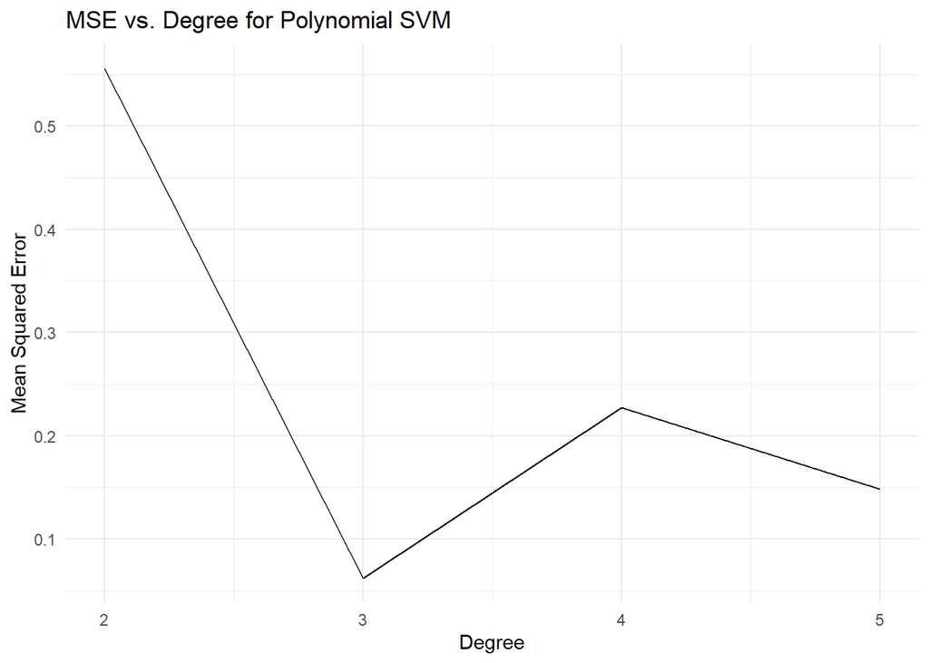

```r
set.seed(123)
degree_values <- seq(2, 5)
mse_values_poly <- numeric(length(degree_values))
r_squared_values_poly <- numeric(length(degree_values))

# Loop through different degrees and fit SVM models
for (i in seq_along(degree_values)) {
  svm_model_poly <- svm(overallRating ~ ., data = train_data, kernel = "polynomial", cost = 1, degree = degree_values[i])

  predictions_poly <- predict(svm_model_poly, newdata = test_data)

  mse_values_poly[i] <- mean((test_data$overallRating - predictions_poly)^2)

  r_squared_values_poly[i] <- 1 - sum((test_data$overallRating - predictions_poly)^2) / sum((test_data$overallRating - mean(test_data$overallRating))^2)
}

plot_data_poly <- data.frame(Degree = degree_values, MSE = mse_values_poly, R_squared = r_squared_values_poly)

ggplot(plot_data_poly, aes(x = Degree, y = MSE)) +
  geom_line() +
  labs(title = "MSE vs. Degree for Polynomial SVM", x = "Degree", y = "Mean Squared Error") +
  theme_minimal()
```

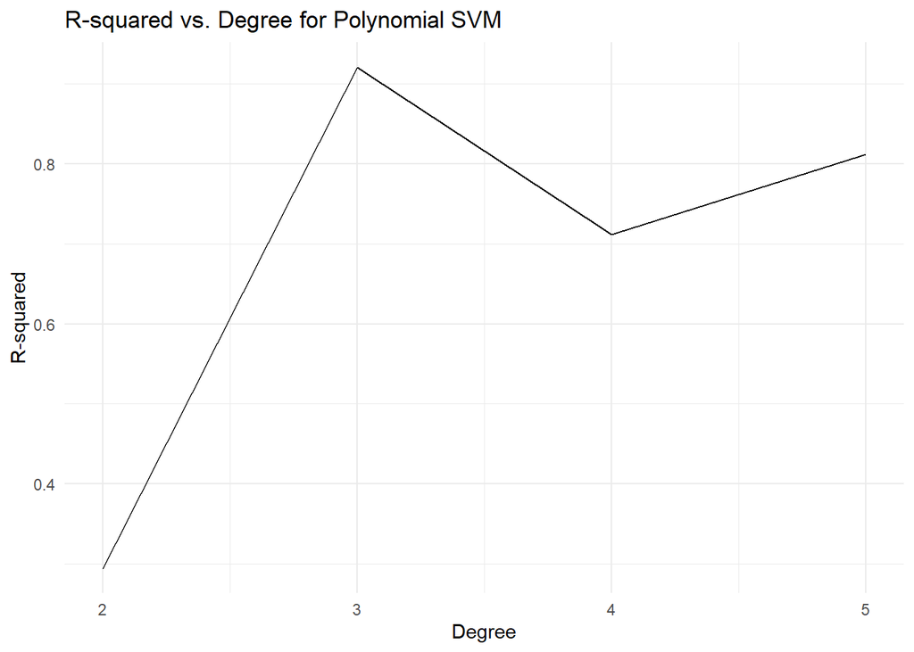

```r
ggplot(plot_data_poly, aes(x = Degree, y = R_squared)) +
  geom_line() +
  labs(title = "R-squared vs. Degree for Polynomial SVM", x = "Degree", y = "R-squared") +
  theme_minimal()
```

It seems that we are achieving the best polynomial kernel performance with degree. We will thus use a degree of 3 in the subsequent hyperparameter tunings.

Let us vary the margin of the model by running cross validation on different cost values.

```r
set.seed(123)
tuning_grid <- expand.grid(cost = c(0.001, 0.01, 0.1, 1, 5, 10, 20, 30, 40))

svm_tuned <- tune(svm, overallRating ~ ., data = train_data, kernel = "polynomial", degree=3, ranges = tuning_grid)

best_model <- svm_tuned$best.model

predictions <- predict(best_model, newdata = test_data)

mse <- mean((test_data$overallRating - predictions)^2)
r_squared <- 1 - sum((test_data$overallRating - predictions)^2) / sum((test_data$overallRating - mean(test_data$overallRating))^2)

cat("Best Tuning Parameters:", best_model$cost, "for cost\n")
```

```
## Best Tuning Parameters: 5 for cost
```

```r
cat("Mean Squared Error:", mse, "\n")
```

```
## Mean Squared Error: 0.06538444
```

```r
cat("R-squared:", r_squared, "\n")
```

```
## R-squared: 0.9170161
```

Based on the output, it seems that best value for cost in a polynomial kernel is 5. However, it is still lower than the performance achieved with a linear kernel.

### SVM with Radial kernel

The final kernel we will try is the radial kernel. We will initally start with cost of 1 and gamma 0.01 before trying other values.

```r
set.seed(123)
svm_model_radial <- svm(overallRating ~ ., data = train_data, kernel = "radial", gamma = 0.01, cost = 1)

predictions <- predict(svm_model_radial, newdata = test_data)

mse_radial <- mean((test_data$overallRating - predictions)^2)
cat("Mean Squared Error:", mse_radial, "\n")
```

```
## Mean Squared Error: 0.05106622
```

```r
r_squared_radial <- 1 - sum((test_data$overallRating - predictions)^2) / sum((test_data$overallRating - mean(test_data$overallRating))^2)
cat("R-squared:", r_squared_radial, "\n")
```

```
## R-squared: 0.9351883
```

This resulted in an R-squared better than the polynomial kernel but worse than the linear kernel. However this is not the best model we can get as we still did not tune the hyperparameters.

Let us run cross-validation on the gamma and cost hyperparameters.

```r
set.seed(123)
tuning_grid <- expand.grid(gamma = c(0.001, 0.01, 0.1, 1, 5, 10), cost = c(0.001, 0.01, 0.1, 1, 10, 20, 30))

svm_tuned <- tune(svm, overallRating ~ ., data = train_data, kernel = "radial", ranges = tuning_grid)

best_model <- svm_tuned$best.model

predictions <- predict(best_model, newdata = test_data)

mse <- mean((test_data$overallRating - predictions)^2)
r_squared <- 1 - sum((test_data$overallRating - predictions)^2) / sum((test_data$overallRating - mean(test_data$overallRating))^2)

cat("Best Tuning Parameters: Gamma =", best_model$gamma, "and Cost =", best_model$cost, "\n")
```

```
## Best Tuning Parameters: Gamma = 0.001 and Cost = 10
```

```r
cat("Mean Squared Error:", mse, "\n")
```

```
## Mean Squared Error: 0.0465061
```

```r
cat("R-squared:", r_squared, "\n")
```

```
## R-squared: 0.9409759
```

Based on the cross-validation, the best gamma and cost values for the radial kernel are 0.001 and 10 respectively. With these values, we get better results than the polynomial and linear kernels, with the result being almost equal to that of the linear kernel but only very slightly higher. This tells us that the flexibility of the radial kernel was able to capture the data distribution properly. We also expect our data to be more linear in nature since the linear kernel was performing almost equally well.

## SVM or Trees?

As we have seen, we achieved the best SVM model with radial kernel and it reached an MSE of 0.0465061. With the trees, our best performing model was the decision tree, with an MSE of 0.28942. When comparing the two models, we can conclude that the SVM outperforms the decision tree. This is expected since trees take the average of the different regions in a regression problem or might fail to find the best split.

# Principle Component Analysis (PCA)

We use PCA as a dimensionality reduction technique to extract a new set of variable or principal components that will explain the variability of the data and the relationship with our response variable `overallRating`. PCA is relevant in our case because our data is multivariate with 13 features. PCA will help us reduce the dimensionality without losing information.

We start by excluding our categorical features and our response variable. We decided not to include the categorical features when performing PCA since it will likely not result in meaningful variance. This is because after one-hot encoding, our features have a covariance matrix with zero-off diagonal elements (the column values of a row will be mutually exclusive as only one of them can be 1).

Hence, the principal components will just be a rotation of the binary space and will not result in informative insights about patterns in the original categorical data.

```r
conflicts_prefer(dplyr::select)
```

```
## [conflicted] Will prefer dplyr::select over any other package.
```

```r
set.seed(123)
numeric_column_names<-c("clearUnderstanding","intellectuallySimulating","goodStructure","materialsUsefulness","clearRequirements","feedbackReceived","learningOutcome","TotalResponses","classSize","ResponseRate","Year", "Semester","noAcademics")
numeric_columns <- data %>% select(all_of(numeric_column_names))
corr_matrix <- cor(numeric_columns)
data.pca <- princomp(corr_matrix)
summary(data.pca)
```

```
## Importance of components:
##                           Comp.1    Comp.2     Comp.3     Comp.4     Comp.5
## Standard deviation     1.1821514 0.4560942 0.38157500 0.29735344 0.19916096
## Proportion of Variance 0.7348151 0.1093808 0.07655819 0.04649195 0.02085644
## Cumulative Proportion  0.7348151 0.8441959 0.92075405 0.96724600 0.98810244
##                             Comp.6      Comp.7       Comp.8       Comp.9
## Standard deviation     0.117416885 0.060013580 0.0423909280 0.0378776863
## Proportion of Variance 0.007249248 0.001893786 0.0009448823 0.0007543949
## Cumulative Proportion  0.995351692 0.997245478 0.9981903600 0.9989447549
##                             Comp.10      Comp.11      Comp.12 Comp.13
## Standard deviation     0.0325812236 0.0244713398 0.0186144501       0
## Proportion of Variance 0.0005581702 0.0003148816 0.0001821932       0
## Cumulative Proportion  0.9995029251 0.9998178068 1.0000000000       1
```

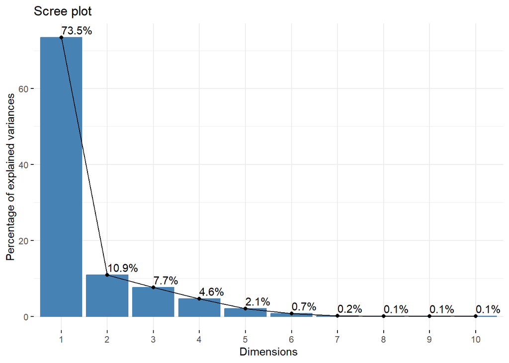

```r
fviz_eig(data.pca, addlabels = TRUE)
```

Our PCA has generated 13 different components(since our maximum components is the number of numerical variables, which is 13). We are interested in looking at the values of each of `Proportion of variance` and `Cumulative proportion`.

`Comp 1` has a proportion variance of 73.5%, which means that this component explain 73.5% of the variability in the data by itself. We see how other components have much smaller impacts on the variance. Naturally, the more components we add, the more our cumulative proportion increases, till reaching 100% by using all components.

Thus, we are interested in using as many components necessary as to decrease dimensionality, while explaining most of the variance.

We decide to keep `Comp1` , `Comp 2` with proportion variance of 73.5%, 10.9% respectively, as to achieve a cumulative proportion of 84% which we deem high enough.

```r
data.pca$loadings[, 1:2]
```

```
##                                Comp.1      Comp.2
## clearUnderstanding        0.359795350  0.08508062
## intellectuallySimulating  0.347425612  0.03894699
## goodStructure             0.362474627  0.07668381
## materialsUsefulness       0.354056548  0.09831312
## clearRequirements         0.342406141  0.08093909
## feedbackReceived          0.353142094  0.03289822
## learningOutcome           0.340166389  0.06311087
## TotalResponses           -0.175290622  0.40858397
## classSize                -0.247552014  0.41142932
## ResponseRate              0.188136078 -0.11965433
## Year                     -0.009959548  0.50158298
## Semester                 -0.034716567 -0.57929926
## noAcademics              -0.082011956 -0.16240969
```

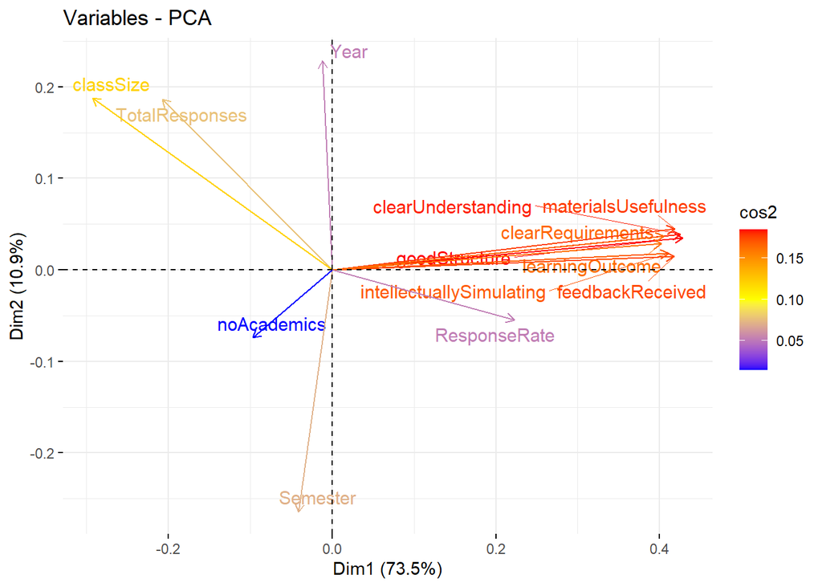

```r
fviz_pca_var(data.pca, col.var = "cos2",
            gradient.cols = c("blue", "yellow", "red"),
            repel = TRUE)
```

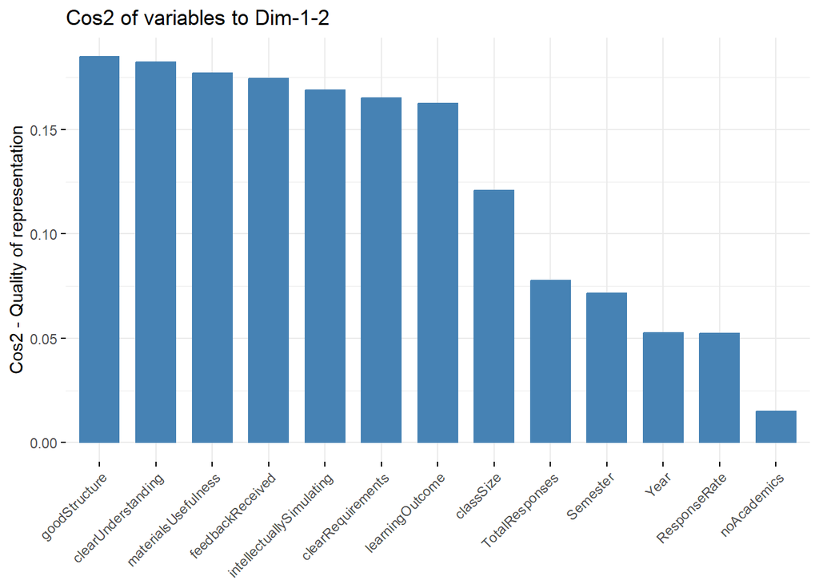

```r
fviz_cos2(data.pca, choice = "var", axes = 1:2)
```

- Good Structure, Material Usefulness, Clear Understanding, feedback Received, and Intellectual Stimulating are all variables with high square cosine value, thus they are the variables that contribute the most to our components. They are colored in red.
- As seen by the bar graph and by their proximity to the origin, noAcademics, Response Rate, year, semester and totalResponses are the least represented variables in our components.
- We see that Response Rate, class Size and total response are of opposites sides of the origin, which means that they are negatively correlated.
- No of academics, and the 7 question variables are also negatively correlated, meaning that a higher number of academics would generally lead to lower scores in these variables.

# KMEANS Clustering

```r
k<-4
numerical_data <- data[,numeric_column_names]

# Perform k-means clustering
set.seed(123)
km.out <- kmeans(numerical_data, centers = k, nstart = 20)
km.out
```

```
## K-means clustering with 4 clusters of sizes 101, 101, 128, 113
##
## Cluster means:
##   clearUnderstanding intellectuallySimulating goodStructure materialsUsefulness
## 1          0.1647128                0.2138852     0.2361738           0.2110538
## 2          1.0265419                0.9887090     1.0274387           1.0529345
## 3          0.3556387                0.3121044     0.3232272           0.3041712
## 4         -1.1417249               -1.0085448    -1.1522082          -1.1409683
##   clearRequirements feedbackReceived learningOutcome TotalResponses   classSize
## 1         0.1438188       0.09813997       0.2079824     -0.0077465 -0.02757723
## 2         1.0170729       1.09834663       0.9941539     -0.1539619 -0.39820928
## 3         0.2935183       0.29514495       0.2974042     -0.1801321 -0.17629700
## 4        -1.1887497      -1.07480556      -1.0320375     -0.1564700 -0.05003479
##   ResponseRate        Year    Semester   noAcademics
## 1  -0.14620696  0.51696234 -0.97637007  0.1681401874
```

[output cut: 60 more lines]

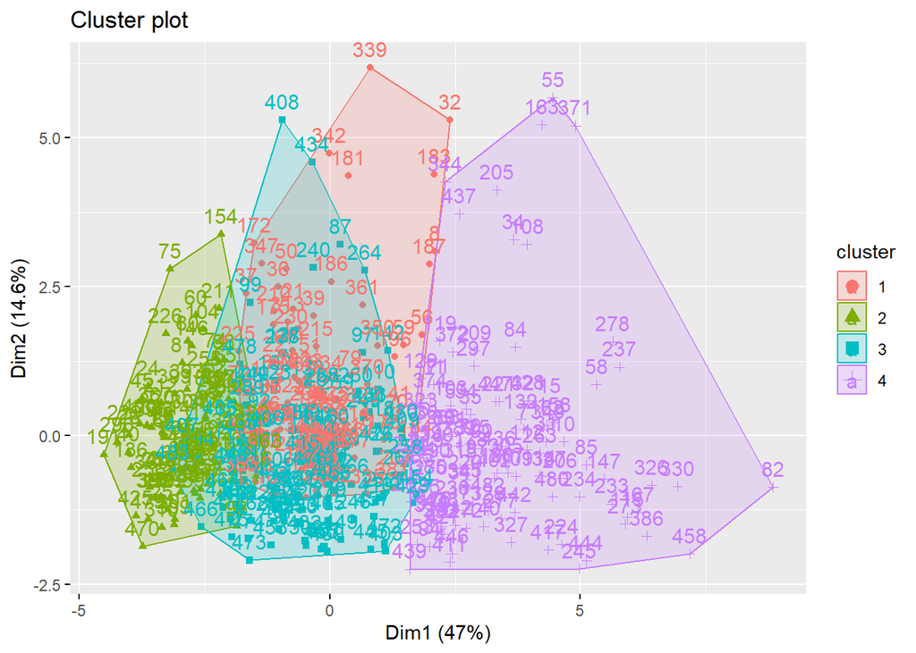

```r
fviz_cluster(km.out, data = numerical_data)
```

In order to determine the number of clusters K, we will go for the elbow method. We will plot the Within Cluster Sum of Squares for multiple values of K, and determine the breaking point using the elbow method. The “elbow” is the point where the rate of decrease of the WCSS slows down.

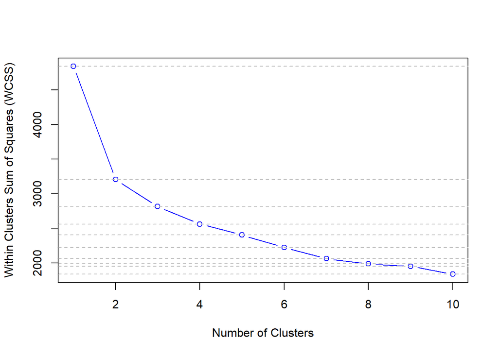

```r
wssplot <- function(data, nc, seed, line_color="blue"){
  wss <- (nrow(data)-1)*sum(apply(data, 2, var))
  for (i in 2:nc){
    set.seed(seed)
    wss[i] <- sum(kmeans(data, centers=i)$withinss)
  }
  plot(1:nc, wss, type = "b", xlab = "Number of Clusters", ylab = "Within Clusters Sum of Squares (WCSS)", col=line_color)
  # Add horizontal dashed lines at each data point on the y-axis
  for (i in 1:nc) {
    abline(h = wss[i], col = "gray", lty = 2)
  }
  wss
}
find_optimal_k <- function(wss_values) {
  # Calculate the second derivative of WSS
  wss_diff <- diff(diff(wss_values))
  print(wss_diff)
  # Find the index corresponding to the maximum second derivative
  elbow_index <- which.max(wss_diff) + 1

  # Return the optimal k
  optimal_k <- elbow_index + 1  # Adjust for 1-based indexing
  return(optimal_k)
}

wss_values <- wssplot(numerical_data, nc = 10, seed = 123)
```

```r
wss_values
```

```
##  [1] 4841.158 3205.174 2815.193 2563.169 2404.489 2224.424 2062.195 1986.253
##  [9] 1952.020 1838.209
```

```r
optimal_k <- find_optimal_k(wss_values)
```

```
## [1] 1246.00237  137.95811   93.34293  -21.38506   17.83697   86.28640   41.70882
## [8]  -79.57723
```

```r
optimal_k
```

```
## [1] 3
```

From the plotted graph,we can see that K= 2 and K=3 seems like good choices. On the other hand, from the result of calculating the elbow point using the second derivative, we get a value K=3. Let’s explore hierarchical clustering and see what results it yields.

# Hierarchal clustering

We will perform hierarchical clustering on different types of linkage, output our resulting dendograms and compare the results.

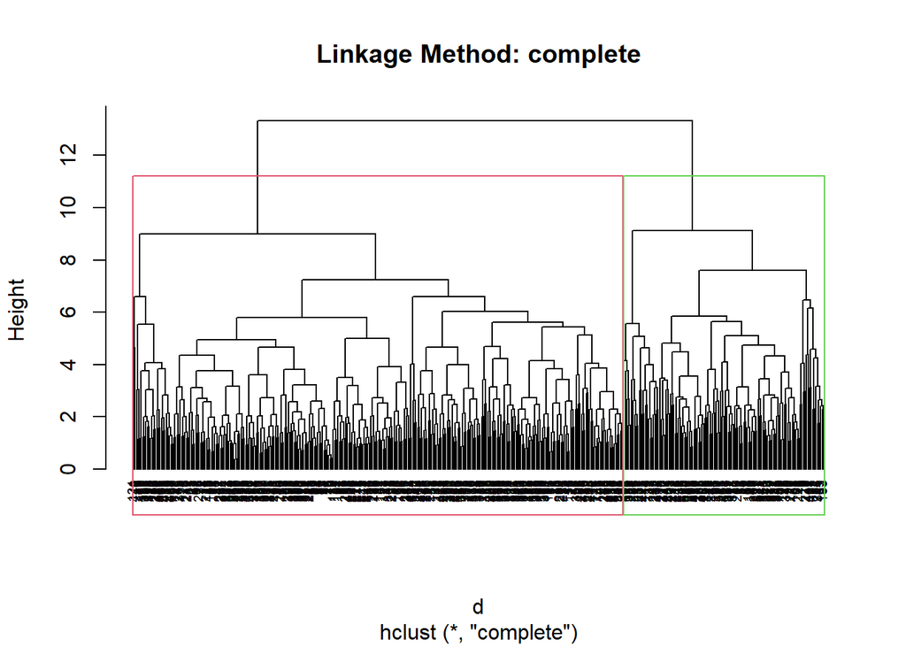

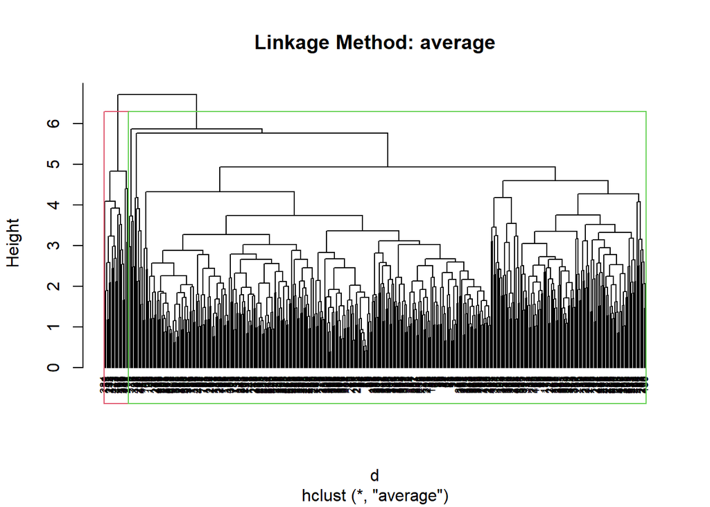

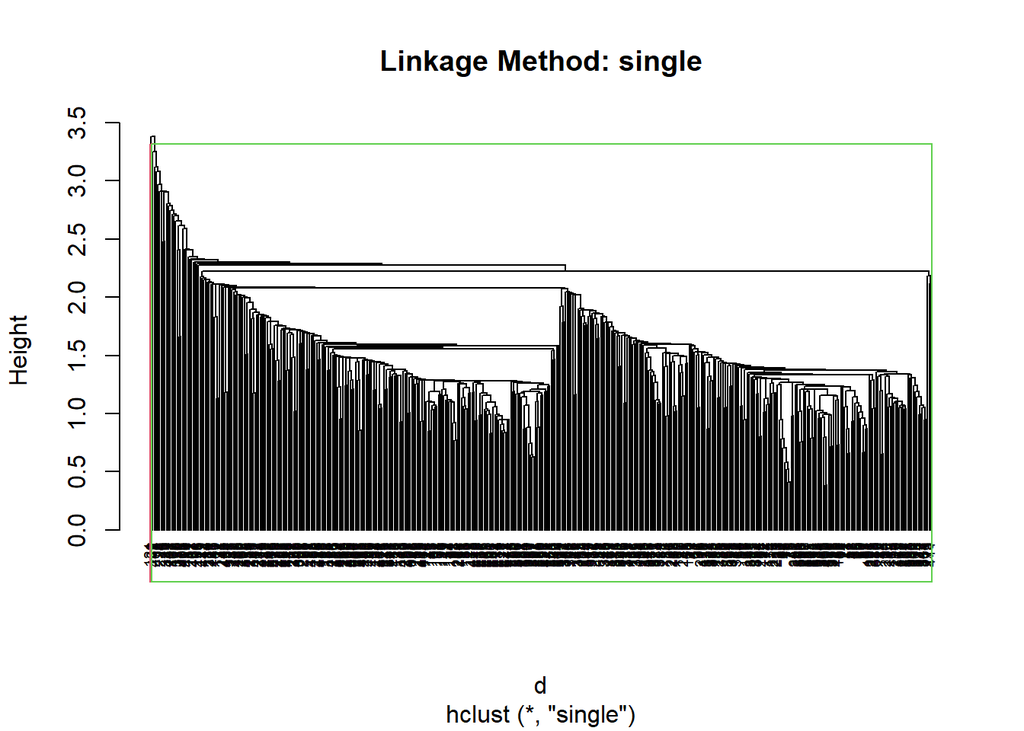

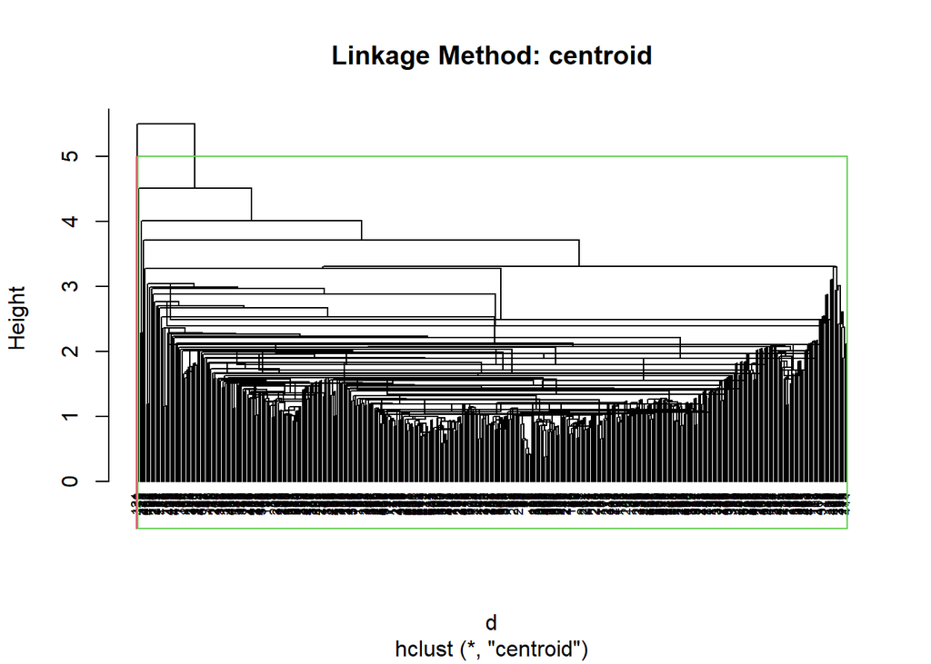

```r
linkage_methods <- c("complete", "average","single", "centroid")
for (method in linkage_methods) {

  d <- dist(numerical_data, method = "euclidean")
  hc <- hclust(d, method = method)
  sub_grp <- cutree(hc, k = 2)

  plot(hc, main = paste("Linkage Method:", method), cex = 0.6, hang = -1)
  rect.hclust(hc, k = 2, border = 2:4)

}
```

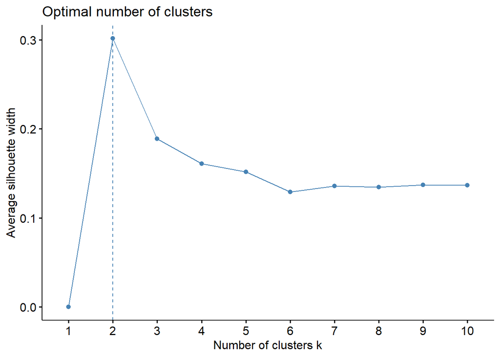

```r
fviz_nbclust(numerical_data, FUN = hcut, method = "silhouette")
```

As we are interested in the distribution of the features in these clusters, we plot a heat map that will showcase was each cluster includes.

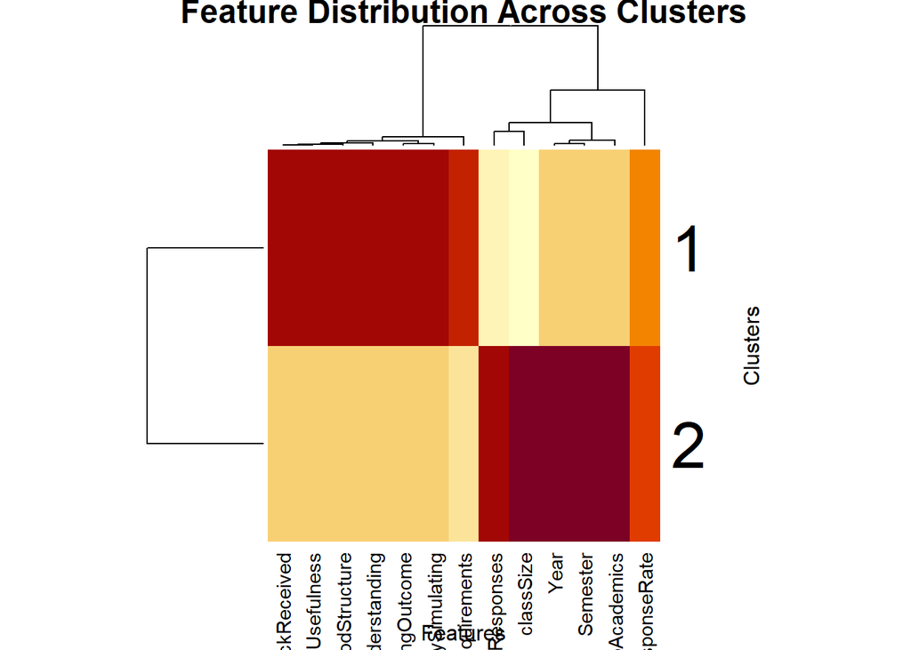

```r
d <- dist(numerical_data, method = "euclidian")
hc <- hclust(d, method = "complete")
sub_grp <- cutree(hc, k = 2)
clustered_data <- split(numerical_data, sub_grp)
cluster_means <- lapply(clustered_data, colMeans)
heatmap_data <- do.call(rbind, cluster_means)
heatmap(heatmap_data, main = "Feature Distribution Across Clusters", xlab = "Features", ylab = "Clusters")
```

The results of the heat map show that the observations were divided into two clusters which align with the groupings that we have seen so far in the data (the question responses are clustered, while other factors are clustered). However, it is more interesting to understand how observation are clstered based on the students’ assesment of the questions, rather than other objective course factors.

Thus, we repeat the same process but only include feature Q1 to Q7.

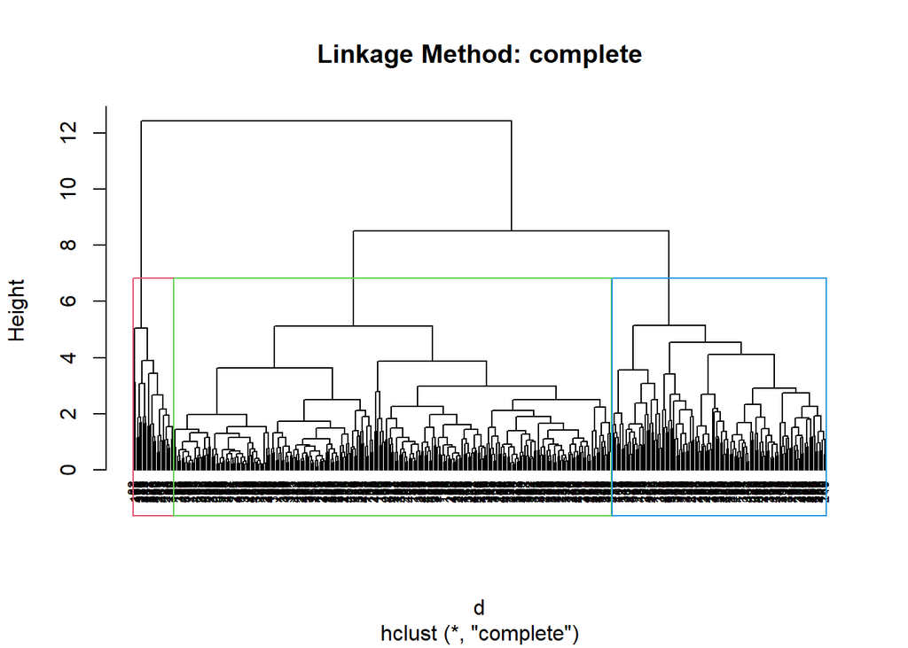

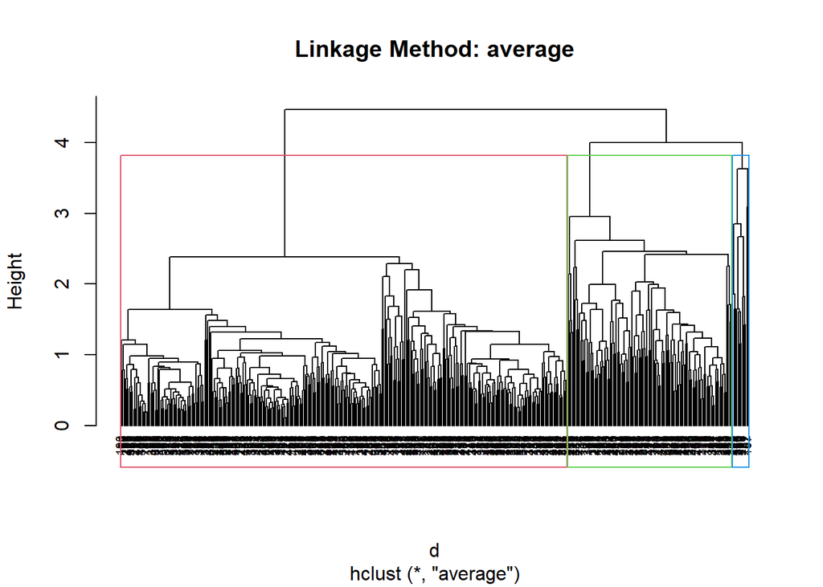

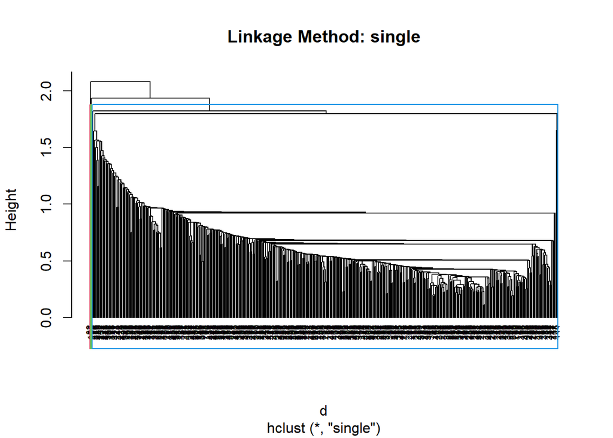

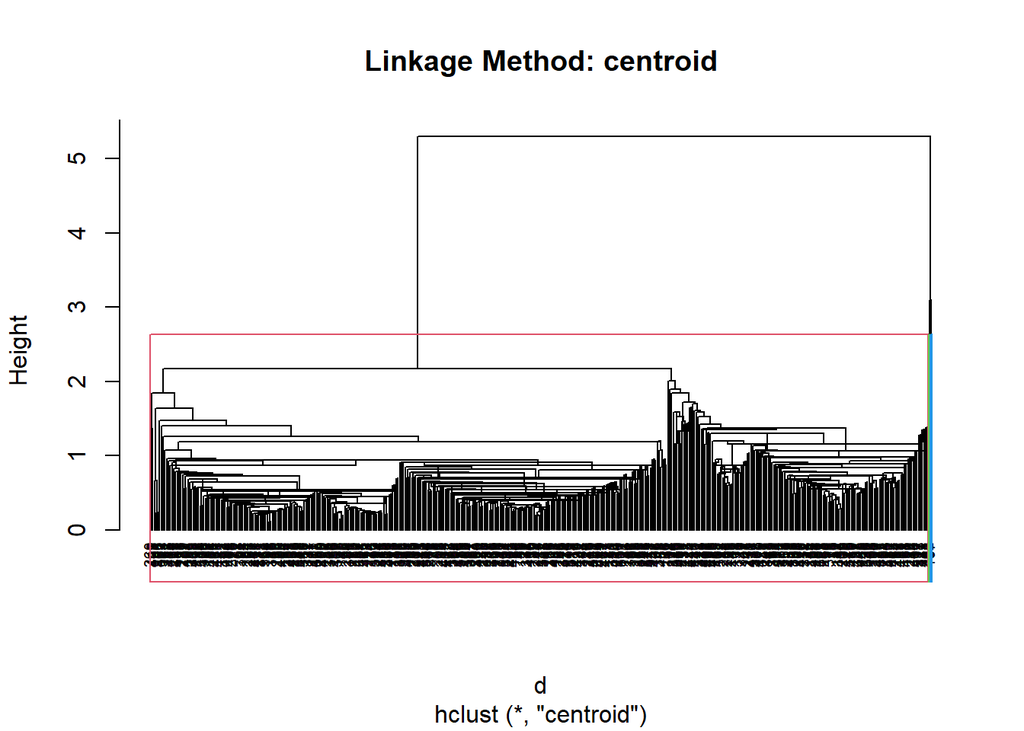

```r
questions_column_names<-c("clearUnderstanding","intellectuallySimulating","goodStructure","materialsUsefulness","clearRequirements","feedbackReceived","learningOutcome")
questions_data<-data[,questions_column_names]
for (method in linkage_methods) {

  d <- dist(questions_data, method = "euclidean")
  hc <- hclust(d, method = method)
  sub_grp <- cutree(hc, k = 3)

  plot(hc, main = paste("Linkage Method:", method), cex = 0.6, hang = -1)
  rect.hclust(hc, k = 3, border = 2:4)

}
```

As we can see, the dendograms now display a different clustering, with K=3 looking like an optimal cut. We then proceed to graph our heat map base don that.

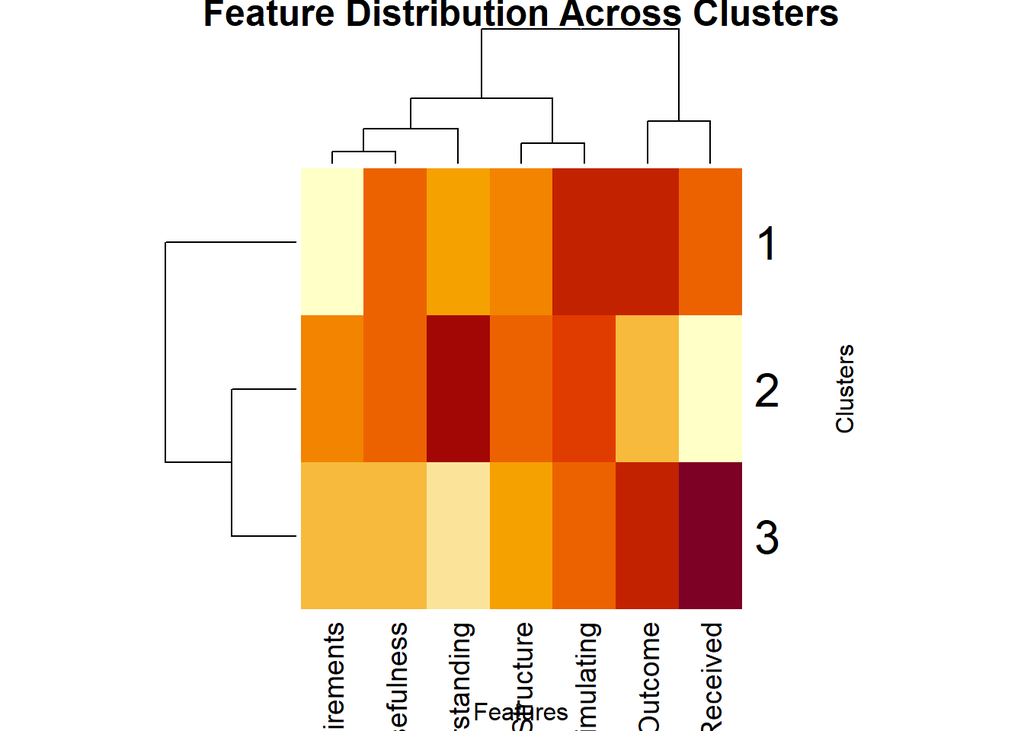

```r
d <- dist(questions_data, method = "euclidian")
hc <- hclust(d, method = "complete")
sub_grp <- cutree(hc, k = 3)
clustered_data <- split(questions_data, sub_grp)
cluster_means <- lapply(clustered_data, colMeans)
heatmap_data <- do.call(rbind, cluster_means)
heatmap(heatmap_data, main = "Feature Distribution Across Clusters", xlab = "Features", ylab = "Clusters")
```

# Conclusion

In this report, we used a dataset of course evaluations compiled over multiple years from the University of Queensland, Australia. Touching upon the goals identified earlier in the problem selection, our findings were as follows:

- SVM Model with radial kernel, gamma of 0.001 and cost of 10 resulted in the best prediction model when compared to different tree models.
- The factors involved in the class environment and teaching method are much more relevant to the overall course rating compared to more objective factors like the class size, campus, gender, etc.

Future work includes collecting more data about the details of the learning environment like activities, projects and other coursework that will help us identify which of these components resulted in factors such as clear understanding, intellectually simulating.. etc which were related with higher ratings.